# Time-Series Modelling of S&P 500 Volatility

# Introduction

Financial markets are inherently dynamic, characterized by fluctuations in asset prices driven by economic conditions, investor sentiment, and external events. Volatility, which measures the degree of variation in asset prices over time is measured by the standard deviation of returns. It is a critical metric for investors, traders, and policymakers. Accurately forecasting volatility helps in portfolio risk management, option pricing, and algorithmic trading. While numerous statistical and machine learning approaches exist for predicting stock prices, forecasting volatility presents unique challenges. Unlike stock prices, volatility exhibits clustering effects, where periods of high volatility tend to be followed by more high volatility and vice versa. Additionally, volatility often demonstrates long-range dependence and seasonality, making simple linear models inadequate for capturing its behavior. In this study, we aim to forecast the volatility of the S&P 500 using a combination of statistical and time series modeling techniques, including ARIMA, SARIMA, and GARCH models.

# Data Exploration

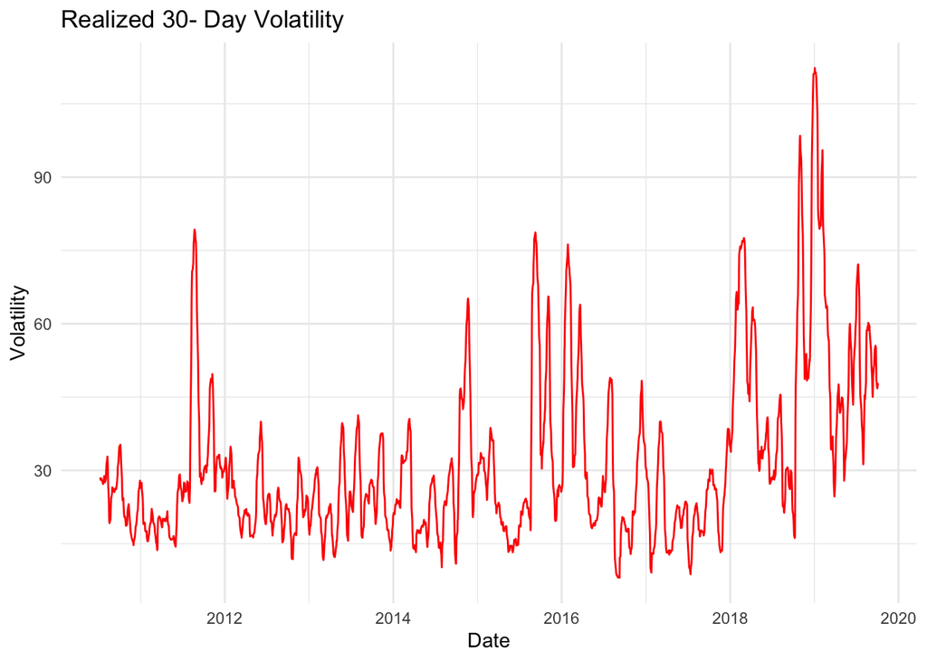

The time-series plot of realized 30-day volatility in the S&P 500 index shows instances of high volatility in certain periods, particularly around 2011, 2015-2016, and 2018-2019. Next we plot the histogram to understand its distribution.

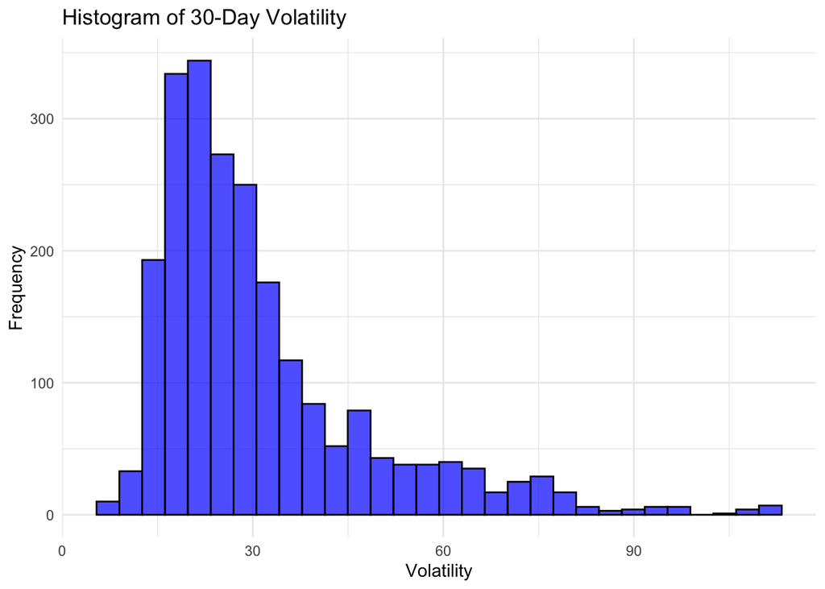

The histogram of 30-day volatility is right-skewed, indicating that lower volatility levels are more frequent, while extreme volatility spikes occur less often.

## Stationarity and Autocorrelation

To ensure the suitability of our time series for modeling, we performed the KPSS (Kwiatkowski-Phillips-Schmidt-Shin) test to assess stationarity. We use the KPSS test instead of the ADF (Augmented Dickey-Fuller) test because KPSS directly tests for stationarity, whereas ADF tests for non-stationarity. The ADF test has low power in detecting stationarity, especially in trend-stationary processes or with structural breaks. A p-value of 0.01 in the initial test suggests strong evidence against stationarity, indicating the presence of a unit root and the necessity of transformation.

To address this, we applied first-order differencing and re-evaluated stationarity using the KPSS test. The resulting p-value of 0.1 indicates that the differenced series is now stationary at the 5% significance level.

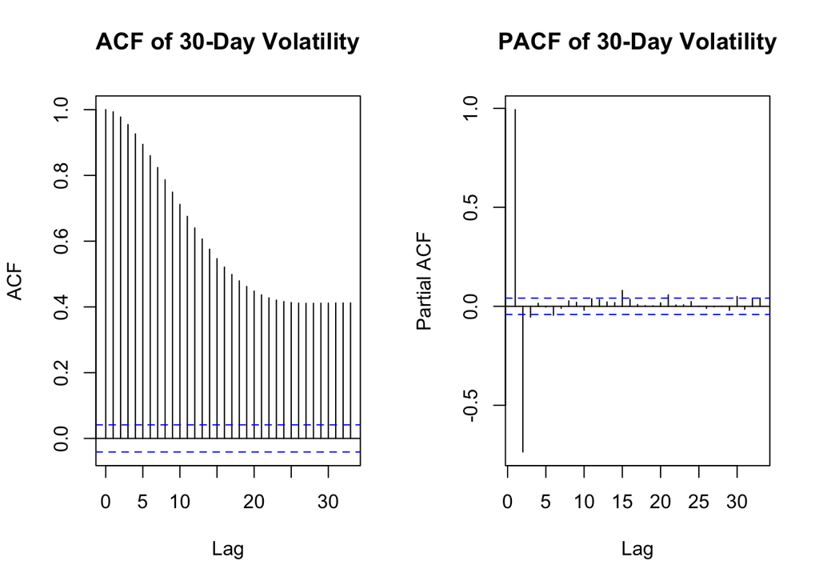

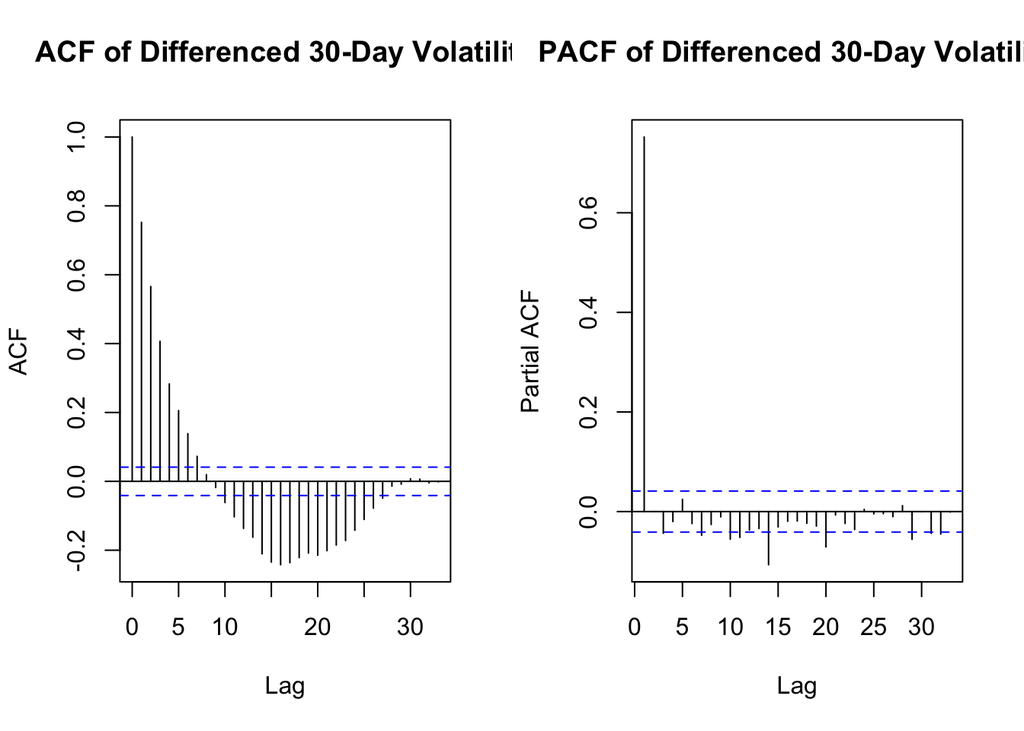

Looking at the ACF and PACF plots, we observe that before differencing, the ACF plot shows a slow decay, reinforcing the presence of a unit root and confirming that the series is non-stationary. The PACF plot exhibits a strong lag-1 autocorrelation, suggesting potential autoregressive behavior. After differencing, the ACF of the differenced series now decays more rapidly, indicating improved stationarity. The PACF of the differenced series shows a significant spike at lag 1, suggesting a possible AR(1) process.

# Spectral Analysis

To analyze the underlying patterns in S&P 500 30-day realized volatility, we apply spectral analysis, which helps identify dominant periodic cycles and long-term trends. We begin with STL decomposition, which separates the series into trend, seasonal, and remainder components. Assuming a 30-day cycle, the decomposition reveals a clear seasonal pattern, a smooth trend reflecting long-term volatility movements, and a remainder component capturing short-term fluctuations.

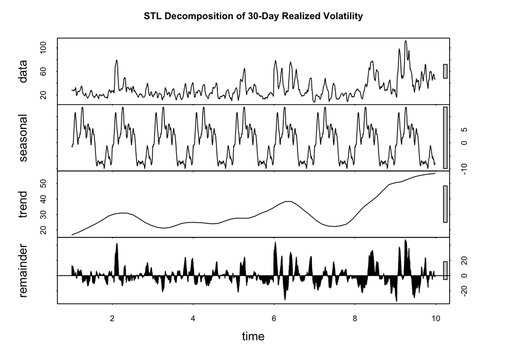

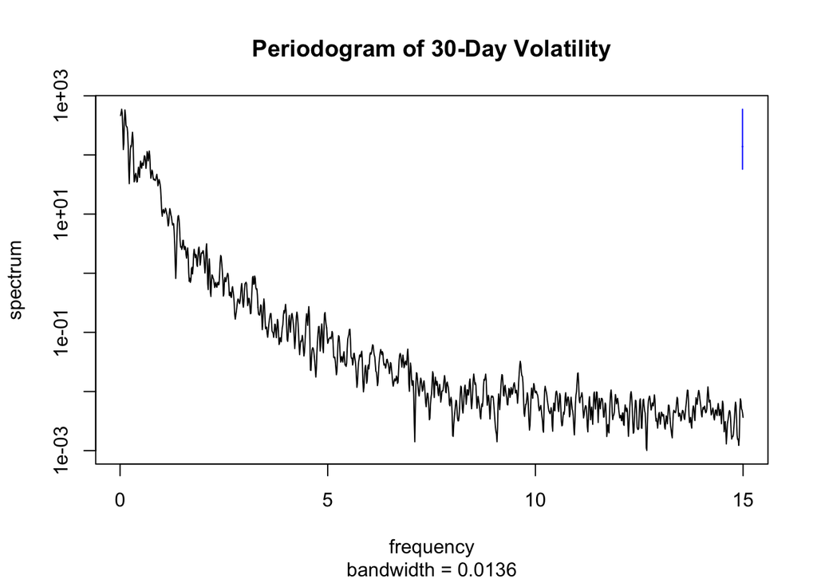

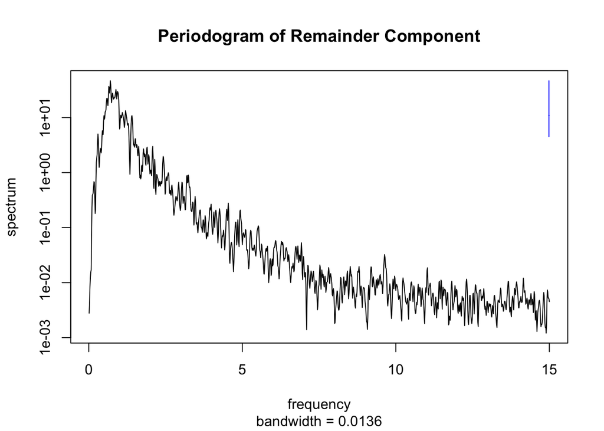

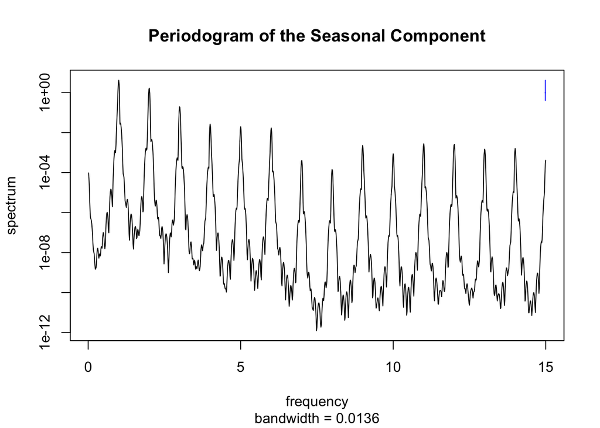

# Model Selection and Residual Diagnostics:

## ARIMA Model

### Model Selection

Based on our data analysis in the previous sections, according to the KPSS test, we find that the original data is not stationary but it becomes stationary after we take a first order difference, therefore we decide to fit an Autoregressive Integrated Moving Avergage Model with $d = 1$, namely $ARIMA(p,1,q)$. Generally, Autoregressive Integrated Moving Avergae Model $ARIMA(p,d,q)$ with intercept $\mu$ for $Y_{1:N}$ can be expressed mathematically as follows (Chapter 4: Linear time series models and the algrebra of ARMA models) :

$$\phi(B)[(1-B)^dY_n-\mu] = \varphi(B)\epsilon_n$$

where

$$\begin{aligned}
\phi(x) &= 1-\phi_1x-\phi_2x^2...-\phi_px^p \\
\psi(x) &= 1+\psi_1x+\psi_2x^2+...+\psi_qx^q \\
\{\epsilon_n\} & \sim WN(\sigma^2) \quad \text{White Noise Process}
\end{aligned}$$

Or equivalently, if we denote $Z_n = \Delta Y_n = Y_n-Y_{n-1}$, it becomes an $ARMA(p, q)$ with intercept $\mu$ for $Z_{1:N}$

$$\phi(B)[Z_n-\mu] = \varphi(B)\epsilon_n \quad \Leftrightarrow \quad
Z_n = \mu
+\phi_1Z_{n-1}+...+\phi_pZ_{n-p}+\varphi_1\epsilon_{n-1}+...+\varphi_q\epsilon_{n-q}+\epsilon_n$$

In order to determine the best model, we use grid search for different $(p, q)$ pairs with $p, q \in\{0, 1, 2, 3, 4, 5\}$ based on Akaike Information Criterion (AIC) values$^{5}$, (Chapter 5: Parameter estimation and model identification for ARMA models). We make an AIC comparison table and choose the model with the lowest AIC value as our best model.

```
#>
#>
#> |    |     MA0|     MA1|     MA2|     MA3|     MA4|     MA5|
#> |:---|-------:|-------:|-------:|-------:|-------:|-------:|
#> |AR0 | 9399.70| 8222.29| 7818.12| 7615.05| 7569.98| 7548.99|
#> |AR1 | 7514.74| 7516.74| 7514.23| 7515.32| 7515.59| 7516.61|
#> |AR2 | 7516.74| 7462.95| 7515.78| 7464.35| 7465.86| 7460.78|
#> |AR3 | 7514.42| 7462.72| 7464.45| 7505.50| 7467.02| 7462.71|
#> |AR4 | 7515.52| 7464.36| 7466.03| 7452.55| 7452.37| 7506.44|
#> |AR5 | 7516.15| 7466.14| 7466.87| 7455.45| 7454.37| 7455.57|
#>
#> Call:
#> arima2::arima(x = data, order = c(p, 1, q))
#>
#> Coefficients:
#>          ar1      ar2     ar3      ar4      ma1     ma2      ma3     ma4
#>       1.5529  -1.3738  1.5322  -0.7445  -0.8257  0.8093  -1.0163  0.0474
#> s.e.  0.0236   0.0415  0.0455   0.0250   0.0321  0.0328   0.0276  0.0292
#>
#> sigma^2 estimated as 1.562:  log likelihood = -3717.18,  aic = 7452.37
#>
#> Training set error measures:
#>                      ME     RMSE       MAE         MPE     MAPE      MASE
#> Training set 0.02321607 1.249679 0.7737026 -0.01862958 2.676067 0.6375112
#>                      ACF1
#> Training set 0.0001374949
#>
#> Call:
#> arima2::arima(x = data, order = c(p, 1, q))
#>
#> Coefficients:
#>          ar1      ar2     ar3      ar4      ma1     ma2      ma3
#>       1.5364  -1.3797  1.5505  -0.7400  -0.7825  0.7879  -0.9917
#> s.e.  0.0146   0.0176  0.0192   0.0153   0.0042  0.0065   0.0060
#>
#> sigma^2 estimated as 1.563:  log likelihood = -3718.28,  aic = 7452.55
#>
#> Training set error measures:
#>                    ME     RMSE       MAE        MPE     MAPE      MASE
#> Training set 0.024446 1.249789 0.7730323 -0.0163492 2.669868 0.6369588
#>                     ACF1
#> Training set -0.02655297
```

Based on the AIC comparison table, the $ARIMA(4, 1, 3)$ and $ARIMA(4, 1, 4)$ can be the potential candidates of our best model as their AIC values are almost the same, which means they fit our data almost equally well. However, after extracting the summary of these two models, we notice that in the $ARIMA(4, 1, 4)$ model, the MA(4) coefficient is 0.0474, which is significantly smaller than other AR and MA coefficients and indicates potential overfitting issue. Therefore, we further conduct a likelihood ratio test to determine if it is necessary to include an extra ma4 term based on $ARIMA(4, 1, 3)$.

$$\begin{aligned}
H_0: \quad ARIMA(4, 1, 3) \\
H_1: \quad ARIMA(4, 1, 4)
\end{aligned}$$

```
#> Likelihood ratio test
#>
#> Model 1: arima2::arima(x = data, order = c(p, 1, q))
#> Model 2: arima2::arima(x = data, order = c(p, 1, q))
#>   #Df  LogLik Df  Chisq Pr(>Chisq)
#> 1   8 -3718.3
#> 2   9 -3717.2  1 2.1842     0.1394
```

The p-value of the likelihood ratio test is 0.1394 > 0.05. Therefore, we fail to reject our null hypothesis, we claim $ARIMA(4, 1, 3)$ as our best model and further specify its model structure.

$$\phi(B)[(1-B)Y_n] = \psi(B)\epsilon_n$$

where
$$\begin{aligned}
\phi(x) &= 1-\phi_1x-\phi_2x^2-\phi_3x^3-\phi_4x^4 \\
\psi(x) &= 1+\psi_1x+\psi_2x^2+\psi_3x^3\\
\{\epsilon_n\} & \sim WN(\sigma^2) \quad \text{White Noise Process}
\end{aligned}$$

### Model Diagnosis

#### Causality and Invertibility

We want to check the causality and invertibility$^{5}$, (Chapter 6: Extending the ARMA model: Seasonality, integration and trend) of our $ARIMA(4, 1, 3)$ model, and visualize the roots on the complex plane.

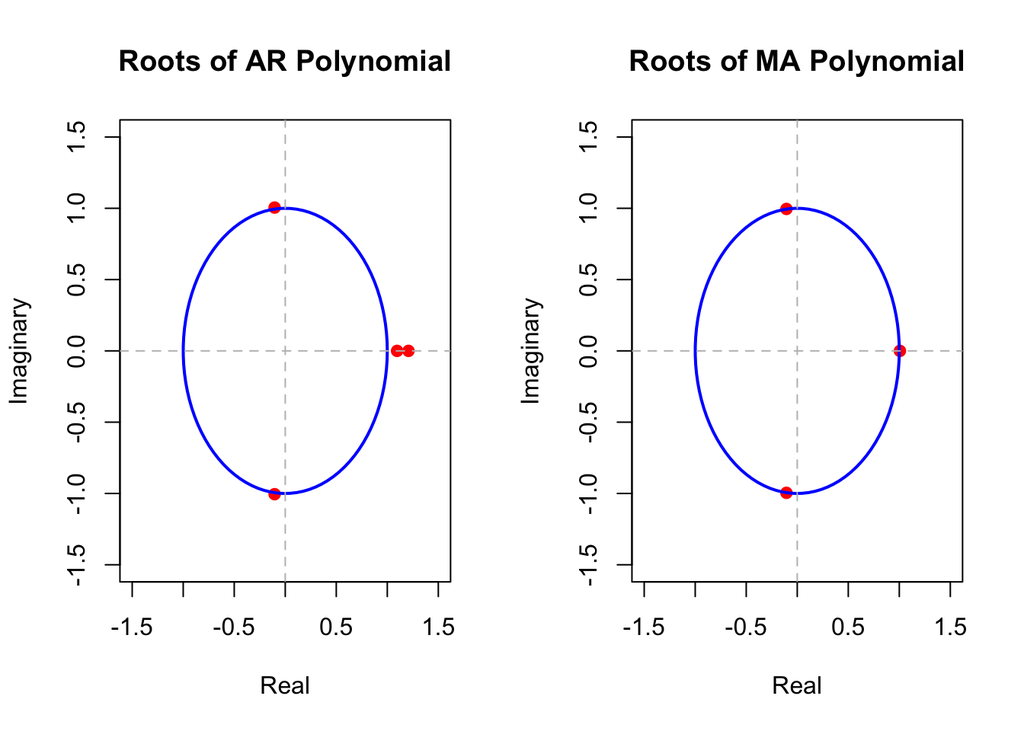

```
#> If the AR polynomial roots outside the unit circle: TRUE TRUE TRUE TRUE
#> If the MA polynomial roots outside the unit circle: TRUE TRUE TRUE
```

#### Residual Analysis

We perform residual diagnosis by using *checkresiduals()* function in the forecast package and making a additional QQ-plot to further check the normality assumption. The *checkresiduals()* call will give four outcomes, one hypothesis test the Ljung-Box test, and three plots including a time plot of the residuals, the corresponding ACF, and a histogram with an added standard normal density curve.

The Ljung-Box test, which is designed as follows:
$$\begin{aligned}
H_0 : &\quad \text{The data is not correlated} \\
H_1 : &\quad \text{The data exhibit serial correlation} \\
\end{aligned} \\
\text{Test Statistics:} \quad Q=n(n+2) \sum_{k=1}^h
\frac{\hat{\rho}_k^2}{n-k}$$

where $n$ is the sample size, $\hat{\rho}_k$ is the sample autocorrelation at lag $k$, and $h$ is the number of lags being tested. Under $H_0$ the statistic $Q$ asymptotically follows a $\chi_{(h)}^2$. For significance level $\alpha$, the critical region for rejection of the hypothesis of randomness is:

$$Q>\chi_{1-\alpha, h}^2$$

where $\chi_{1-\alpha, h}^2$ is the $(1-\alpha)$-quantile of the chi-squared distribution with $h$ degrees of freedom.

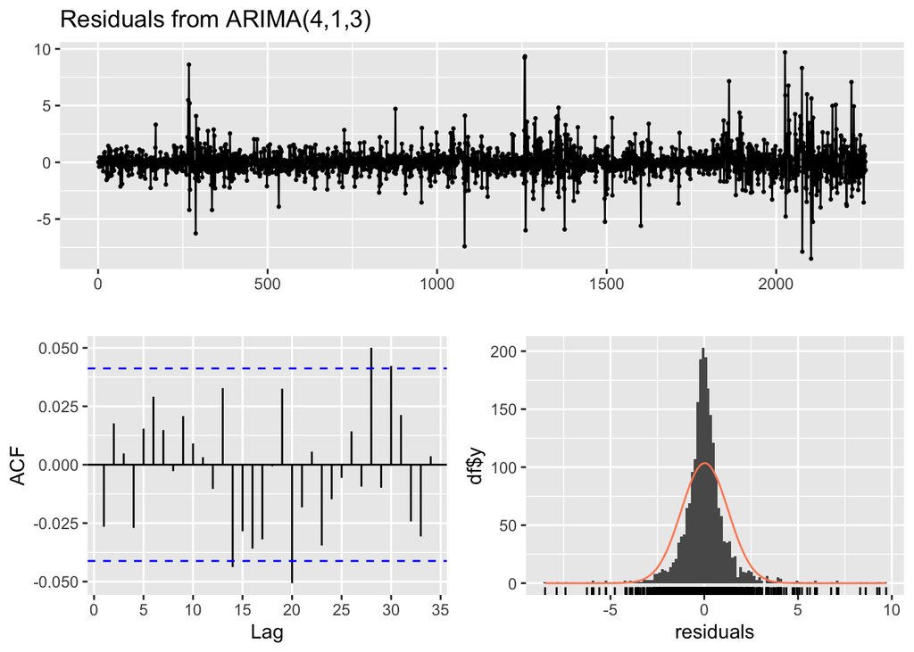

```
#>
#>  Ljung-Box test
#>
#> data:  Residuals from ARIMA(4,1,3)
#> Q* = 30.674, df = 13, p-value = 0.003762
#>
#> Model df: 7.   Total lags used: 20
```

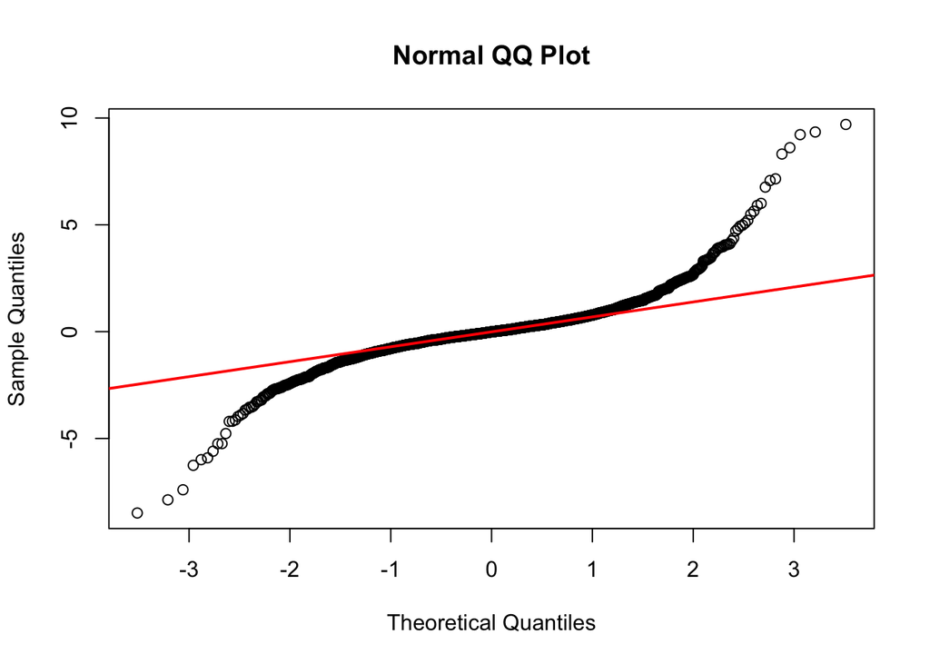

Therefore, we can make the following claims on residuals of our $ARIMA(4, 1, 3)$ model:

1. The residuals are correlated.

   As the Ljung-Box test gives a p-value of 0.003762 < 0.05, which means we reject our null hypothesis that the residuals are not correlated; and the residuals ACF plot also indicates that there are significant autocorrelations in residuals at lag 14, 20, 28.
2. The residuals approximately have mean 0, but the variance seems unstable.

   From the time plot of the residuals, the residuals approximately oscillate around 0, but the variance seems unstable as several sharp peaks appear before the residual of the 2000th data point and general larger variations after the residual of the 2000th data point.
3. The residuals are not normally distributed.

   As the histogram shows that the residuals have significantly larger density near 0 compared with the standard normal distribution, and the QQ plot indicates the residuals have heavy tails in both negative and positive directions.

## SARIMA Model

### Model Selection

As literature in finance analysis and our frequency analysis above indicate a possible 30 days cycle period in our daily data set, we consider including seasonality with period 30 based on our previous $ARIMA(4, 1, 3)$ model, and check if adding seasonality leads to a better fit. Therefore, we further define our $SARIMA(4, 1, 3)\times(P, D, Q)_{30}$ as follows$^5$ (Chapter 5 : Parameter estimation and model identification for ARMA models):

$$\begin{aligned}
\phi(B) &\Phi\left(B^{30}\right)\left[(1-B)\left(1-B^{12}\right)^D
Y_n-\mu\right]=\psi(B) \Psi\left(B^{30}\right) \epsilon_n \\
&\phi(B) = 1-\phi_1B-\phi_2B^2-\phi_3B^3-\phi_4B^4 \\
&\psi(B) = 1+\psi_1B+\psi_2B^2+\psi_3B^3\\
&\Phi(B^{30}) = 1-\Phi_1B^{30}-...-\Phi_PB^{30} \\
&\Psi(B^{30}) = 1+\Psi_1B^{30}+...+\Psi_QB^{30} \\
&\{\epsilon_n\} \sim WN(\sigma^2) \quad \text{White Noise Process}
\end{aligned}$$

After we try to fit $SARIMA(4, 1, 3)\times(P, D, Q)_{30}$, we find that $P, D, Q$ take values larger than 2 will significantly increase model complexity and cause errors, therefore, we try to search the best model among $SARIMA(4, 1, 3)\times(1, 0, 0)_{30}$, $SARIMA(4, 1, 3)\times(0, 0, 1)_{30}$, $SARIMA(4, 1, 3)\times(1, 1, 0)_{30}$, $SARIMA(4, 1, 3)\times(0, 1, 1)_{30}$, and $SARIMA(4, 1, 3)\times(1, 1, 1)_{30}$ models.

```
#> The the 5 th model has the lowest AIC value.
```

We can see that the model5 $SARIMA(4, 1, 3)\times(1, 1, 1)_{30}$ has the lowest AIC value, but it is larger than the AIC value given by our previous $ARIMA(4, 1, 3)$ model. We extract the summary and specify our model structure as follows:

```
#> Series: data$SP500.30.Day.Volatility
#> ARIMA(4,1,3)(1,1,1)[30]
#>
#> Coefficients:
#>          ar1      ar2      ar3     ar4      ma1      ma2     ma3    sar1
#>       1.8173  -0.5228  -0.5668  0.2631  -1.0945  -0.2541  0.3525  0.0311
#> s.e.  0.5913   1.3668   1.0633  0.2840   0.5977   0.9687  0.4110  0.0228
#>          sma1
#>       -0.9725
#> s.e.   0.0126
#>
#> sigma^2 = 1.61:  log likelihood = -3740.61
#> AIC=7501.23   AICc=7501.33   BIC=7558.34
#>
#> Training set error measures:
#>                    ME     RMSE       MAE        MPE     MAPE      MASE
#> Training set 0.018755 1.257512 0.7832486 -0.0216991 2.727618 0.6453768
#>                     ACF1
#> Training set 0.001167352
```

$$\begin{aligned}
\phi(B) &\Phi\left(B^{30}\right)\left[(1-B)\left(1-B^{12}\right)
Y_n-\mu\right]=\psi(B) \Psi\left(B^{30}\right) \epsilon_n \\
&\phi(x) = 1-\phi_1x-\phi_2x^2-\phi_3x^3-\phi_4x^4 \\
&\psi(x) = 1+\psi_1x+\psi_2x^2+\psi_3x^3\\
&\Phi(x^{30}) = 1-\Phi_1x^{30} \\
&\Psi(x^{30}) = 1+\Psi_1x^{30} \\
&\{\epsilon_n\} \sim WN(\sigma^2) \quad \text{White Noise Process}
\end{aligned}$$

### Residual Analysis

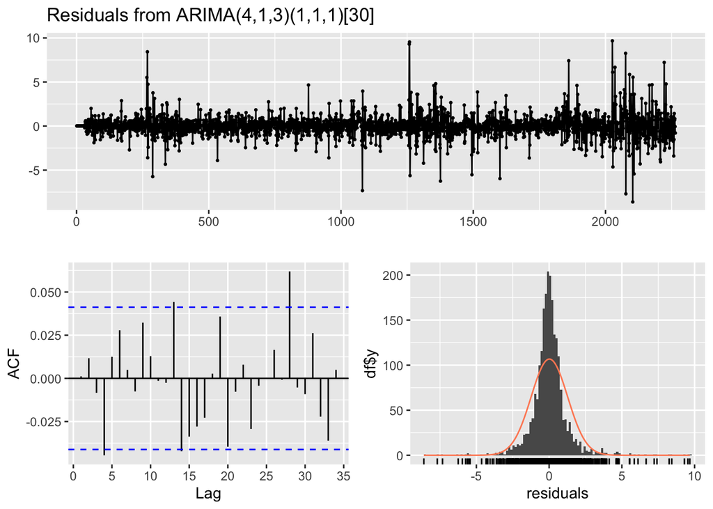

```
#>
#>  Ljung-Box test
#>
#> data:  Residuals from ARIMA(4,1,3)(1,1,1)[30]
#> Q* = 30.655, df = 11, p-value = 0.001249
#>
#> Model df: 9.   Total lags used: 20
```

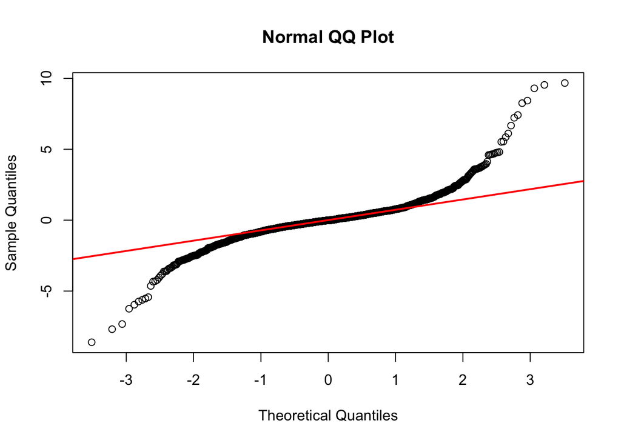

After fitting the $SARIMA(4, 1, 3)\times(1, 1, 1)_{30}$ model, similar conclusions of residuals can be drawn, therefore $SARIMA(4, 1, 3)\times(1, 1, 1)_{30}$ fitting is still not satisfying, which further indicate that the seasonality in our data is not very strong and cannot improve our model fitting. Therefore, we should consider a more complex model, an ARMA+GARCH model with varying variance and non-normal errors (actually we tried student t errors, but we failed in model explanation and diagnosis, therefore we still stick to normal errors in the ARMA+GARCH model).

## ARMA+GARCH Model

### Mathematical Background and Model Derivation

Financial time series often exhibit *volatility clustering*: periods during which high volatility tends to be followed by high volatility and low volatility by low volatility. Traditional ARMA models focus on capturing the linear dynamics of the conditional mean but assume a constant variance. However, empirical evidence shows that the variance (or volatility) of financial returns is time-varying. This observation motivates the use of the **GARCH (Generalized Autoregressive Conditional Heteroscedasticity)** model, which explicitly models the evolving conditional variance.

#### Model Formulation

We begin by decomposing the observed return series $r_t$ as follows$^8$:

$$r_t = \sigma_t z_t,\quad z_t \sim N(0,1),$$

where:

- $z_t$ is a standard normal random variable,
- $\sigma_t$ is the conditional standard deviation (i.e., the volatility) at time $t$.

This formulation separates the scale (e.g. volatility) from the standardized noise, allowing us to model the time-varying behavior of volatility independently.

In contrast, a traditional ARMA model typically expresses the conditional mean as:
$$r_t = \mu + \sum_{i=1}^{p} \phi_i\, r_{t-i} + \sum_{j=1}^{q} \theta_j\,
\varepsilon_{t-j} + \varepsilon_t,$$

where the error term $\varepsilon_t$ is assumed to be white noise with a constant variance. This constant variance assumption is inadequate for financial data exhibiting heteroscedasticity.

#### GARCH Model

To address the shortcomings of the constant variance assumption, Bollerslev (1986) introduced the GARCH model$^8$. The most common specification is the GARCH(1,1) model, in which the conditional variance is defined as:
$$\sigma_t^2 = \omega + \alpha\, r_{t-1}^2 + \beta\, \sigma_{t-1}^2,$$

with:

- $\omega > 0$ ensuring a baseline variance,
- $\alpha \geq 0$ capturing the immediate impact of past shocks,
- $\beta \geq 0$ measuring the persistence of past volatility.

This recursive formulation allows the model to capture volatility clustering. A large shock (high $r_{t-1}^2$) increases $\sigma_t^2$, and if $\beta$ is also high, the elevated volatility persists for several periods.

#### Forecasting and Parameter Estimation

**Forecasting:**
Assuming that future standardized shocks satisfy $E[z_{t+h}^2] = 1$, the one-step-ahead forecast for the conditional variance is:
$$\sigma_{t+1}^2 = \omega + \alpha\, r_t^2 + \beta\, \sigma_t^2.$$

For multi-step forecasting, this formula is iterated recursively.

**Parameter Estimation:**
The parameters $\omega$, $\alpha$, and $\beta$ are typically estimated via Maximum Likelihood Estimation (MLE). Under the assumption of normally distributed innovations, the log-likelihood function for a sample of size $n$ is given by$^9$ :
$$\mathcal{L} = -\frac{1}{2} \sum_{t=1}^{n} \left[ \log(2\pi) +
\log(\sigma_t^2) + \frac{r_t^2}{\sigma_t^2} \right].$$

Maximizing this log-likelihood function with respect to the model parameters yields the estimates that best explain the observed data.

All in all, while ARMA models are effective for modeling the conditional mean of a time series, they fall short in capturing the time-varying nature of volatility observed in financial data. The GARCH model overcomes this limitation by dynamically modeling the conditional variance. This explains the volatility clustering phenomenon and provides a framework for forecasting future volatility.

### Model Fitting

In this section, we provide a detailed introduction to the process of fitting the ARMA-GARCH model and evaluating it using information criteria.

Then, we extract Akaike Information Criterion and Bayesian Information Criterion from each fitting model and store them in the result table. These criteria are used to evaluate model fit, where lower values typically indicate better models. In order to get a more suitable model, we choose to use log transformation because we have tested it seems a bad performance with no transformation. Here gives the results:

```
#>    arma_order garch_order        AIC        BIC
#> 1         0,1         1,1 -0.7768868 -0.7642435
#> 2         0,1         1,2 -0.7749447 -0.7597728
#> 3         0,1         2,1 -0.8137992 -0.7986273
#> 4         0,1         2,2 -0.8129158 -0.7952152
#> 5         1,0         1,1 -3.2162885 -3.2036452
#> 6         1,0         1,2 -3.2213658 -3.2061939
#> 7         1,0         2,1 -3.2173150 -3.2021430
#> 8         1,0         2,2 -3.2204824 -3.2027817
#> 9         1,1         1,1 -3.4650372 -3.4498652
#> 10        1,1         1,2 -3.4644375 -3.4467369
#> 11        1,1         2,1 -3.4668268 -3.4491262
#> 12        1,1         2,2 -3.4659434 -3.4457141
#> 13        2,1         1,1 -3.7023487 -3.6846481
#> 14        2,1         1,2 -3.7026769 -3.6824476
#> 15        2,1         2,1 -3.7014653 -3.6812360
#> 16        2,1         2,2 -3.7020102 -3.6792522
#> 17        1,2         1,1 -3.5873199 -3.5696192
#> 18        1,2         1,2 -3.5867804 -3.5665511
#> 19        1,2         2,1 -3.5864369 -3.5662076
#> 20        1,2         2,2 -3.5887987 -3.5660407
#> 21        2,2         1,1 -3.7015653 -3.6813360
#> 22        2,2         1,2 -3.7019480 -3.6791900
#> 23        2,2         2,1 -3.7006819 -3.6779239
#> 24        2,2         2,2 -3.7012981 -3.6760115
```

### Model Diagnostics

To ensure the adequacy of the fitted model, we conduct diagnostic checks on the residuals. The mathematical derivation of these methods has been discussed in the previous section.

- **QQ Plot of Standardized Residuals**: We plot a QQ plot to assess whether the standardized residuals follow the assumed distribution.

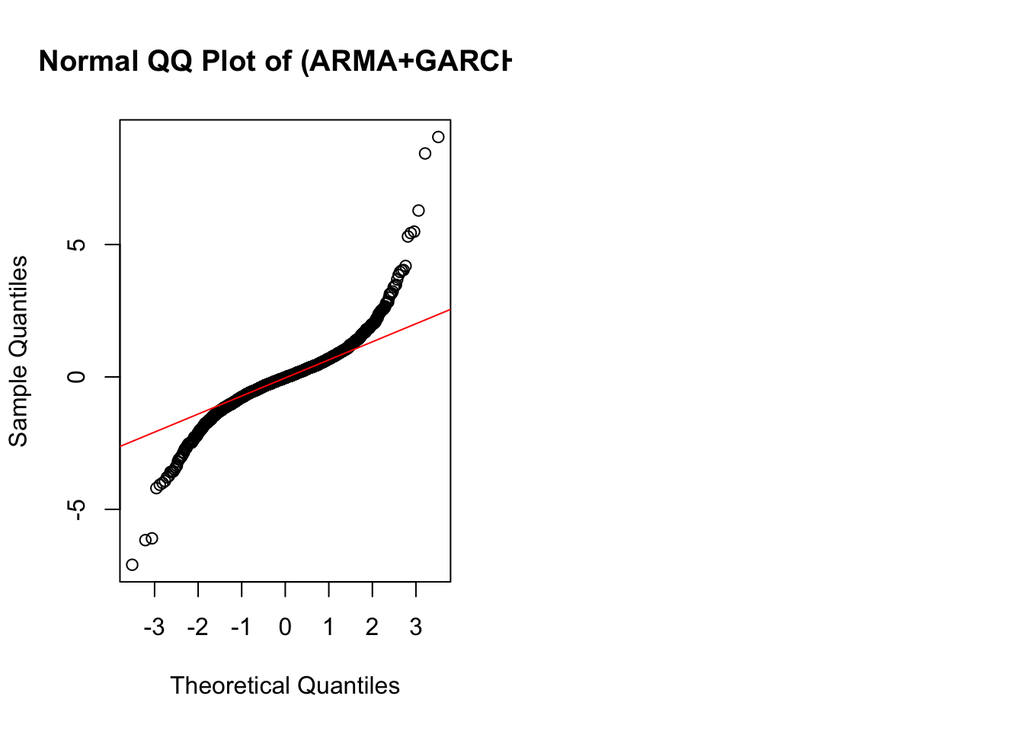

The QQ plot shows a heavy tail and significant deviation from the diagonal reference line, indicating that the residuals may not follow the assumed normal distribution. There are some limitation within our model, which will be discussed more in the limitation part.

- **Residuals analysis**: We plot the autocorrelation function (ACF) and partial autocorrelation function (PACF) of the standardized residuals to identify any remaining temporal patterns.

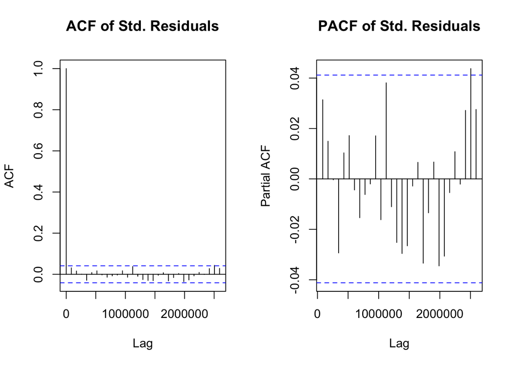

- **Ljung-Box Test**: We perform the Ljung-Box test on the standardized residuals to check for serial correlation.

```
#> Ljung-Box test on standardized residuals p-value: 0.522416
```

# Limitation

Here we want to briefly mention our project’s limitations and give some suggestions on future explorations. Both our ARIMA and SARIMA model fail in the residual checking stage as we find significant correlations and non-normality; after we take a log transformation and change to ARMA+Garch model, these phenomenons become less severe but still exist, especially for the normality assumption, which indicates the necessarity to build a model based on different error distributions such as student-t distribution (actually we tried to do so, but we failed in model explanation and diagnosis) or even more advanced machine learning algorithms such as LSTM. Another potential issue is within our dataset, events such as the European debt crisis and the Federal Reserve’s policy shift between 2010 and 2019 could all lead to a sudden surge in volatility. Also, the recovery phase after the 2008 financial crisis may have introduced structural or institutional changes that cannot be captured by the basic GARCH framework. Besides, volatility clusters may be more extreme or persistent than model assumptions, leading to underestimation of significant shocks.

# Conclusion

In this study, we analyzed and forecasted S&P 500 30-day realized volatility using ARIMA, SARIMA, and ARMA-GARCH models, combining time-domain and frequency-domain techniques. Stationarity testing confirmed the need for first-order differencing, while spectral analysis highlighted periodic patterns in volatility. The ARIMA(4,1,3) model provided a reasonable fit but exhibited residual autocorrelation, and SARIMA failed to significantly improve performance. The ARMA-GARCH model, incorporating volatility clustering, offered the best residual diagnostics, though structural breaks and non-normality remained challenges. Future work could explore GARCH with heavy-tailed distributions or deep learning approaches to better capture complex market dynamics.

# Our Project in Context of Previous Projects

Our project on volatility modelling and trend analysis using ARIMA, SARIMA, and frequency analysis aligns closely with previous STATS 531 projects in methodology but differs in application, focusing on financial market volatility rather than public safety, climate, or cryptocurrency trends. Like past projects, our work relies on autoregressive models, stationarity tests, AIC-based model selection, and decomposition techniques such as STL to extract trends, mirroring the NYC traffic accident analysis for example. Additionally, it shares similarities with a few previous projects in its use of spectral analysis, employing Fourier Transform and Power Spectral Density to uncover periodic volatility patterns. However, our project extends beyond ARIMA-based modelling by incorporating GARCH models to better capture volatility dynamics, a methodology that was not a primary focus in previous projects. Lessons from peer reviews, such as the importance of clearly defining hypotheses, manually validating model selection, addressing model limitations, and improving visualization, have guided our approach to ensure methodological rigor and clarity. Furthermore, our project connects modelling results to financial risk management, ensuring statistical insights translate into actionable economic decisions.

# References

1. Engle, R. F., & Patton, A. J. (2001). *What good is a volatility model?* Quantitative Finance.
2. Poon, S. H., & Granger, C. W. J. (2003). *Forecasting volatility in financial markets: A review.* Journal of Economic Literature, 41(2), 478-539.
3. Kwiatkowski, D., Phillips, P. C. B., Schmidt, P., & Shin, Y. (1992). *Testing the null hypothesis of stationarity against the alternative of a unit root.* Journal of Econometrics, 54(1-3), 159–178.
4. Hyndman, R. J., & Athanasopoulos, G. (2021). *Forecasting: Principles and Practice (3rd ed.)*. Retrieved from https://otexts.com/fpp3/decomposition.html
5. Ionides, E. (2025). [Notes for STATS 531, Modeling and Analysis of Time Series Data](https://ionides.github.io/531w25/).
6. Wikipedia. Ljung-Box test. https://en.wikipedia.org/wiki/Ljung%E2%80%93Box_test.
7. ChatGPT. Used for debugging and proofreading.
8. Galizio, G. Almqvist, W. Keller, G. (2023). *GARCH(1,1) for index returns.* https://github.com/ggstream12/GARCH-model-in-R/blob/main/dissertation.pdf.
9. Wurtz, D. Chalabi, Y. Luksan, L. (2022). *Parameter Estimation of ARMA Models with GARCH/APARCH Errors.* https://www.math.pku.edu.cn/teachers/heyb/TimeSeries/lectures/garch.pdf
10. *A GARCH Tutorial with R*. https://www.redalyc.org/journal/840/84064925005/html/
11. Hofert, M. (2024). *Fitting and Predicting VaR based on an ARMA-GARCH Process.* https://cran.r-project.org/web/packages/qrmtools/vignettes/ARMA_GARCH_VaR.html
12. LIBERTO, D. (2024). *European Sovereign Debt Crisis: Eurozone Crisis Causes, Impacts.* https://www.investopedia.com/terms/e/european-sovereign-debt-crisis.asp
13. *History of the Federal Reserve.* https://www.federalreserveeducation.org/about-the-fed/archive-history/
14. Ionides, E. (2022). *Ethereum and Investment: Midterm Project for STATS 531*. University of Michigan. Retrieved from https://ionides.github.io/531w22/midterm_project/project02/blinded.html. We follow a similar methodology to the one outlined in this project.